# DV Assignment 2, Part 1: [Your Title Here]

### Advice by test results and school disadvantage

To answer the research question, we plotted each school’s advice against its test results, separately for maths and reading. Schools are split into three equal groups by school weighting, and each group has its own regression line.

```r
## Split schools into three equal groups by school weighting
schools <- schools |>
  mutate(
    disadvantage = ntile(schoolweging, 3),
    disadvantage = factor(
      disadvantage,
      levels = 1:3,
      labels = c("Least disadvantaged", "Middle", "Most disadvantaged")
    ),
    pct_below_havo = 1 - pct_havo_plus
  )

## Set colours for the three groups (colourblind-friendly)
disadv_colours <- c(
  "Least disadvantaged" = "#0072B2",
  "Middle" = "#009E73",
  "Most disadvantaged" = "#D55E00"
)

## Set x-axis titles for maths and reading
x_maths <- "Share of pupils at maths target level (1S)"
x_reading <- "Share of pupils at reading target level (2F)"

## Create function that makes one scatterplot
make_scatter <- function(data, x_col, y_col, title, x_label, y_label) {
  ggplot(
    data,
    aes(x = .data[[x_col]], y = .data[[y_col]], colour = disadvantage)
  ) +
    # one dot per school
    geom_point(alpha = 0.15, size = 1) +
    # one regression line per group
    geom_smooth(method = "lm", formula = y ~ x, linewidth = 1.2) +
    scale_colour_manual(values = disadv_colours) +
    scale_x_continuous(labels = scales::percent) +
    scale_y_continuous(labels = scales::percent) +
    # show the full range (0-100%) on both axes
    coord_cartesian(xlim = c(0, 1), ylim = c(0, 1)) +
    labs(title = title, x = x_label, y = y_label) +
    theme_minimal(base_size = 16) +
    theme(legend.position = "none", plot.title = element_text(face = "bold"))
}

## Create function that makes two scatterplots (maths, reading) for one track
make_track_pair <- function(data, track_name) {
  # keep only this track
  track_data <- filter(data, track == track_name)
  y_label <- paste("Share of pupils with", track_name, "advice")
  list(
    make_scatter(
      track_data, "pct_maths_1s", "advice_share",
      title = paste(
        "Pupils with", track_name, "advice\nby school maths results"
      ),
      x_label = x_maths, y_label = y_label
    ),
    make_scatter(
      track_data, "pct_reading_2f", "advice_share",
      title = paste(
        "Pupils with", track_name, "advice\nby school reading results"
      ),
      x_label = x_reading, y_label = y_label
    )
  )
}

## Create one legend for all scatterplots (coloured square + text)
legend_data <- tibble(
  label = names(disadv_colours),
  x = c(0.30, 0.55, 0.68)
)
legend_row <- ggplot(legend_data) +
  # coloured squares
  geom_point(
    aes(x = x, y = 0), shape = 15, size = 9, colour = disadv_colours
  ) +
  # group names next to the squares
  geom_text(aes(x = x + 0.015, y = 0, label = label), hjust = 0, size = 6) +
  # legend title
  annotate(
    "text", x = 0.05, y = 0, label = "School disadvantage:",
    hjust = 0, size = 6
  ) +
  coord_cartesian(xlim = c(0, 1), ylim = c(-1, 1), expand = FALSE) +
  theme_void()
```

#### Split by HAVO+ and below HAVO advice

We first summarised the advice as the share of pupils with HAVO-or-higher advice, and the below HAVO.

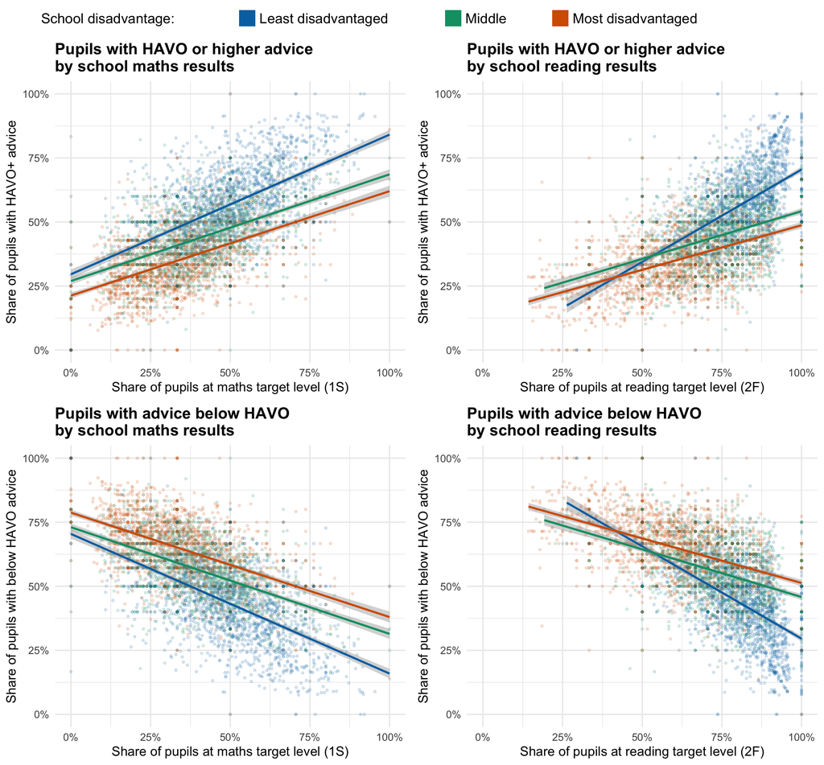

```r
## Scatterplot of HAVO+ advice by maths target level
p_havo_maths <- make_scatter(
  schools, "pct_maths_1s", "pct_havo_plus",
  title = "Pupils with HAVO or higher advice\nby school maths results",
  x_label = x_maths, y_label = "Share of pupils with HAVO+ advice"
)

## Scatterplot of HAVO+ advice by reading target level
p_havo_reading <- make_scatter(
  schools, "pct_reading_2f", "pct_havo_plus",
  title = "Pupils with HAVO or higher advice\nby school reading results",
  x_label = x_reading, y_label = "Share of pupils with HAVO+ advice"
)

## Scatterplot of below HAVO advice by maths target level
p_below_maths <- make_scatter(
  schools, "pct_maths_1s", "pct_below_havo",
  title = "Pupils with advice below HAVO\nby school maths results",
  x_label = x_maths, y_label = "Share of pupils with below HAVO advice"
)

## Scatterplot of below HAVO advice by reading target level
p_below_reading <- make_scatter(
  schools, "pct_reading_2f", "pct_below_havo",
  title = "Pupils with advice below HAVO\nby school reading results",
  x_label = x_reading, y_label = "Share of pupils with below HAVO advice"
)

## Combine legend and the four plots (2 x 2)
havo_plots <- plot_grid(
  p_havo_maths, p_havo_reading, p_below_maths, p_below_reading,
  ncol = 2
)
plot_grid(legend_row, havo_plots, ncol = 1, rel_heights = c(0.05, 1))
```

#### Split by mean advice (1 = PRO to 6 = VWO) (to feedback)

Next, we summarised the advice as the mean advice per school, with tracks scored from 1 (PRO) to 6 (VWO) and split advice in between (e.g. HAVO/VWO = 5.5). We would like feedback on whether mean advice is a suitable summary, because it assumes equal distances between tracks which might not be appropriate.

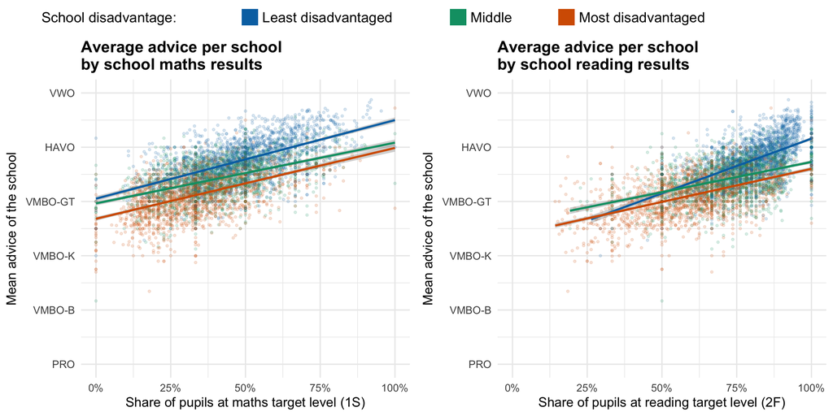

```r
## Set y-axis for mean advice (1 = PRO ... 6 = VWO, full range)
mean_y_axis <- list(
  scale_y_continuous(
    breaks = 1:6,
    labels = c("PRO", "VMBO-B", "VMBO-K", "VMBO-GT", "HAVO", "VWO")
  ),
  coord_cartesian(xlim = c(0, 1), ylim = c(1, 6))
)

## Scatterplot of mean advice by maths target level
p_mean_maths <- make_scatter(
  schools, "pct_maths_1s", "mean_advice",
  title = "Average advice per school\nby school maths results",
  x_label = x_maths, y_label = "Mean advice of the school"
) +
  mean_y_axis

## Scatterplot of mean advice by reading target level
p_mean_reading <- make_scatter(
  schools, "pct_reading_2f", "mean_advice",
  title = "Average advice per school\nby school reading results",
  x_label = x_reading, y_label = "Mean advice of the school"
) +
  mean_y_axis

## Combine legend and the two plots
mean_plots <- plot_grid(p_mean_maths, p_mean_reading, ncol = 2)
plot_grid(legend_row, mean_plots, ncol = 1, rel_heights = c(0.09, 1))
```

#### Split by six main tracks

Finally, we looked at the share of pupils in each of six main tracks (split advice counted as the lower track). At the same test results, it looks like more disadvantaged schools give more advice in the lower tracks (PRO to VMBO-K) and less VWO advice, especially among schools with high results. Visually, however, these figures are hard to read and navigate. We also tried to not use mean advice but all the 10 categories that are present in the data including all the split advices as separate categories but that made the figures simply worse without adding much extra information.

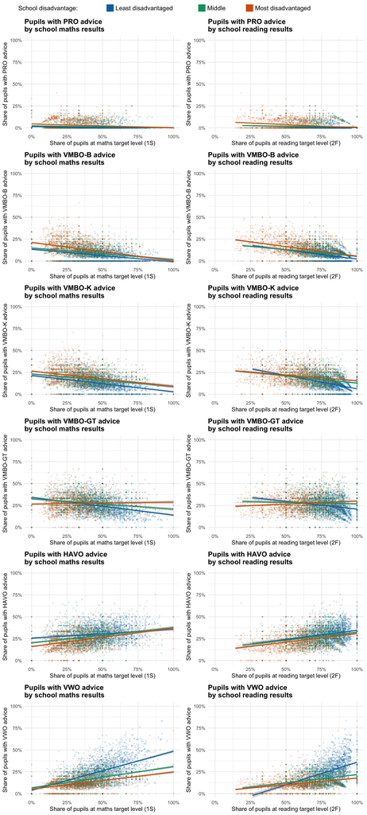

```r
## Compute share per main track (split advice counts as the lower track)
six_long <- schools |>
  transmute(
    INSTELLINGSCODE, disadvantage, pct_maths_1s, pct_reading_2f,
    PRO = PRO / n_groep8,
    `VMBO-B` = (VMBO_B + VMBO_B_K) / n_groep8,
    `VMBO-K` = (VMBO_K + VMBO_K_GT) / n_groep8,
    `VMBO-GT` = (VMBO_GT + VMBO_GT_HAVO) / n_groep8,
    HAVO = (HAVO + HAVO_VWO) / n_groep8,
    VWO = VWO / n_groep8
  ) |>
  # one row per school and track
  pivot_longer(PRO:VWO, names_to = "track", values_to = "advice_share")

## Scatterplots of each main track (maths left, reading right)
six_plots <- c(
  make_track_pair(six_long, "PRO"),
  make_track_pair(six_long, "VMBO-B"),
  make_track_pair(six_long, "VMBO-K"),
  make_track_pair(six_long, "VMBO-GT"),
  make_track_pair(six_long, "HAVO"),
  make_track_pair(six_long, "VWO")
)

## Combine legend and the twelve plots (6 rows x 2 columns)
six_grid <- plot_grid(plotlist = six_plots, ncol = 2)
plot_grid(legend_row, six_grid, ncol = 1, rel_heights = c(0.02, 1))
```